# HyperConvNets

Needing to explore different architectures for a given problem is a common use-case. Many a times, it is a trial and error process where one has to try different configurations of a given architecture and then finally select one that suits a particular porblem.

This notebook explores an idea that allows one to explore different architectures in a very efficient way.

A network of multiple convolutional layers for classifying images from CIFAR10 is used as the example.

High-level structure of the contents:

- Import required packages
- Create dataloaders for the CIFAR10 dataset
- Define a HyperConvNet architecture that allows easy architectural design space exploration
- Train HyperConvNet and explore the validation accuracy for different configurations of increasing sizes
- Compare the classification performance of the HyperConvNet with a configuration where all the layers are trained

It is a continuation of the exploration that started with HyperNet for classifying hand-written digits from MNIST dataset. A notebook for the same can be found in the repository hosting this notebook [HyperNet](https://htmlpreview.github.io/?https://github.com/ansatrawala/pub/blob/main/hypernets/HyperNet-MNIST.html).

# Idea

Imagine if convolutional layers of CNNs (convolutional neural networks) could be trained similiarly to [HyperNet](https://htmlpreview.github.io/?https://github.com/ansatrawala/pub/blob/main/hypernets/HyperNet-MNIST.html)s.

Refer the figure given below. This architecture consists of 5 convolutional layers. Random segments (anchored at the lower end) are trained in each batch. One instance of a training boundary is shown by dashed line. The weights of the kernels at the lower ends are trained more compared to the kernels at top as the training proceeds.

[figure not shown]

The definition of the model and experimental data is shown in the sections below.

# Definitions

```python
import numpy as np
import torch
import torchvision
import matplotlib.pyplot as plt
from time import time
from torchvision import datasets, transforms
from torch import nn, optim
import math

from torchvision.datasets import CIFAR100, CIFAR10
import torchvision.transforms as tt
from torchvision.utils import make_grid
from torch.utils.data.dataloader import DataLoader
from torch.utils.data import random_split, ConcatDataset

%matplotlib inline
```

```python
# Define transforms for processing RGB files of CIFAR10 dataset

stats = ((0.5074,0.4867,0.4411),(0.2011,0.1987,0.2025))

train_transform = tt.Compose([
    tt.RandomHorizontalFlip(),
    tt.RandomCrop(32,padding=4, padding_mode="reflect"),
    tt.ToTensor(),
    tt.Normalize(*stats)
])

test_transform = tt.Compose([
    tt.ToTensor(),
    tt.Normalize(*stats)
])
```

```python
# Create test and validation dataset loaders

batch_size = 128

trainset = CIFAR10('dtrain_cifar10', download=True, train=True, transform=train_transform)
valset = CIFAR10('dvalid_cifar10', download=True, train=False, transform=test_transform)

trainloader = torch.utils.data.DataLoader(trainset, batch_size=batch_size, shuffle=True)
valloader = torch.utils.data.DataLoader(valset, batch_size=batch_size, shuffle=True)
```

```
Files already downloaded and verified
Files already downloaded and verified
```

```python
dataiter = iter(trainloader)
images, labels = dataiter.next()

print(images.shape)
print(labels.shape)
```

```
torch.Size([128, 3, 32, 32])
torch.Size([128])
```

```
Clipping input data to the valid range for imshow with RGB data ([0..1] for floats or [0..255] for integers).
```

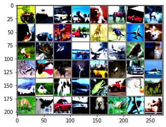

```python
figure = plt.figure()
num_of_images = 48

def imshow(img):
    img = img / 2 + 0.5     # unnormalize
    npimg = img.numpy()
    plt.imshow(np.transpose(npimg, (1, 2, 0)))
    plt.show()

# show images
imshow(torchvision.utils.make_grid(images[0:num_of_images]))
```

```python
input_size = 3*32*32
```

```python
# Function for training a model for one epoch

def train(model, trainloader, criterion, optimizer, extra_model_args = None):

    model.train()

    all_loss = 0
    correct_count, all_count = 0, 0

    for inputs, labels in trainloader:
        # Don't flatten CIFAR10 images into a 3*32*32 i.e. long vector
        #images = images.view(images.shape[0], -1)

        # Training pass
        optimizer.zero_grad()

        if extra_model_args == None:
            outputs = model(inputs)
        else:
            outputs = model(inputs, extra_model_args)

        loss = criterion(outputs, labels)

        #This is where the model learns by backpropagating
        loss.backward()

        #And optimizes its weights here
        optimizer.step()

        # Calculate validation accuracy
        _, predictions = torch.max(outputs.data, 1)
        correct_preds = predictions.eq(labels.data.view_as(predictions))
        # Convert correct_counts to float and then compute the mean
        batch_avg_acc = torch.mean(correct_preds.type(torch.FloatTensor))
        # Compute total accuracy in the whole batch and add to valid_acc
        correct_count += batch_avg_acc.item() * inputs.size(0)

        all_loss += loss.item() * inputs.shape[0]
        all_count += inputs.size(0)
    return (all_loss / all_count, correct_count / all_count)
```

```python
# Function for running a validation run

def validate(model, valloader, criterion, extra_model_args = None):

    model.eval()

    all_loss = 0
    correct_count, all_count = 0, 0

    for inputs, labels in valloader:
        with torch.no_grad():
            if extra_model_args == None:
                outputs = model(inputs)
            else:
                outputs = model(inputs, extra_model_args)

            loss = criterion(outputs, labels)

            # Calculate validation accuracy
            _, predictions = torch.max(outputs.data, 1)
            correct_preds = predictions.eq(labels.data.view_as(predictions))
            # Convert correct_counts to float and then compute the mean
            batch_avg_acc = torch.mean(correct_preds.type(torch.FloatTensor))

            # Compute total accuracy in the whole batch and add to valid_acc
            correct_count += batch_avg_acc.item() * inputs.size(0)

            all_loss += loss.item() * inputs.shape[0]
            all_count += inputs.size(0)
    return (all_loss / all_count, correct_count / all_count)
```

```python
# Definition of hyper-convolutional layer

class HyperConvLayer(nn.Module):
    def __init__(self, input_shape, out_channel_segment_specs):
        super(HyperConvLayer, self).__init__()

        self._input_shape = torch.Size(input_shape)
        batch_size = input_shape[0]
        num_input_channels = input_shape[1]

        w_in = input_shape[2]
        h_in = input_shape[3]

        # create segments of output channels
        segments = nn.ModuleList()
        w_out = None
        h_out = None

        out_channel_sizes = []
        for out_channel_segment_spec in out_channel_segment_specs:
            num_out_channel_segment = out_channel_segment_spec[0]
            out_channel_sizes.append(num_out_channel_segment)

            k = out_channel_segment_spec[1][0]
            s = out_channel_segment_spec[1][1]
            p = out_channel_segment_spec[1][2]

            w_out_seg = math.floor(1 + (w_in + 2 * p - k)/s)
            h_out_seg = math.floor(1 + (h_in + 2 * p - k)/s)

            if w_out == None:
                w_out = w_out_seg
            else:
                assert w_out_seg == w_out, "All the segments in a layer must have same output width"
            if h_out == None:
                h_out = h_out_seg
            else:
                assert h_out_seg == h_out, "All the segments in a layer must have same output height"

            segments.append(
                nn.Sequential(
                    nn.Conv2d(num_input_channels, num_out_channel_segment, kernel_size=k, stride=s, padding=p),
                    nn.BatchNorm2d(num_out_channel_segment),
                    nn.LeakyReLU(0.02)))

        self._segments = segments

        self._output_shape = torch.Size([batch_size, sum(out_channel_sizes), w_out, h_out])

        for m in self.modules():
            if isinstance(m, nn.Conv2d):
                nn.init.kaiming_normal_(m.weight, mode='fan_out', nonlinearity='relu')
            elif isinstance(m, (nn.BatchNorm2d, nn.GroupNorm)):
                nn.init.constant_(m.weight, 1)
                nn.init.constant_(m.bias, 0)

    def forward(self, x_partial, active_segments_spec = "random"):

        num_partial_channels = x_partial.shape[1]

        x_padding_tail = torch.zeros(x_partial.shape[0], self._input_shape[1] - num_partial_channels, self._input_shape[2], self._input_shape[3])

        x_expanded = torch.cat([x_partial, x_padding_tail], dim=1)

        if active_segments_spec == "random":
            # random selection
            num_active_segments = np.random.randint(1, len(self._segments) + 1)
        elif active_segments_spec == "all":
            num_active_segments = len(self._segments)
        else: # has to be a number
            num_active_segments = active_segments_spec

        # do forward pass only for the requested number of segments
        active_segments = self._segments[0:num_active_segments]

        segment_outs = []
        for active_segment in active_segments:
            segment_outs.append(active_segment(x_expanded))

        return torch.cat(segment_outs, dim=1)

    def output_shape(self):
        return self._output_shape
```

```python
# A bit of testing code to check the definition above
conv_layer = HyperConvLayer([128, 3, 32, 32], [(8, (3, 2, 1)), (8, (5, 2, 2))])
print(conv_layer.output_shape())

y = conv_layer.forward(images) # random
y = conv_layer.forward(images, 1)
y = conv_layer.forward(images, "all") # max
```

```
torch.Size([128, 16, 16, 16])
```

```python
# Definition oc Hyper-Convolutional Neural Network
# It supports instantiation with different configurations e.g.

# model = HyperConvNet([batch_size, 3, 32, 32], [
#     [(16, (3, 2, 1)), (16, (5, 2, 2)), (16, (7, 2, 3))],
#     [(16, (3, 2, 1)), (16, (5, 2, 2)), (16, (7, 2, 3))],
#     [(16, (3, 2, 1)), (16, (5, 2, 2)), (16, (7, 2, 3))],
#     [(16, (3, 2, 1)), (16, (5, 2, 2)), (16, (7, 2, 3))],
#     [(16, (3, 2, 1)), (16, (5, 2, 2)), (16, (7, 2, 3))]],
#     128,
#     10)

class HyperConvNet(nn.Module):
    def __init__(self, input_shape, conv_channels_segment_pecs_list, last_fc_size, num_classes):
        super(HyperConvNet, self).__init__()

        #self._conv_channels_segments_list = conv_channels_segments_list.copy()

        self.conv_layers = nn.ModuleList()

        self.conv_layer_out_shapes = []
        prev_layer_shape = input_shape

        for conv_channel_segments_spec in conv_channels_segment_pecs_list:
            hyper_conv_layer = HyperConvLayer(prev_layer_shape, conv_channel_segments_spec)
            self.conv_layers.append(hyper_conv_layer)
            prev_layer_shape = hyper_conv_layer.output_shape()
            self.conv_layer_out_shapes.append(prev_layer_shape)

        self.flatten = nn.Flatten()

        def prod_shape(shape):
            prod = 1
            for v in shape:
                prod *= v
            return prod

        self.fc_size = prod_shape(self.conv_layer_out_shapes[-1][1:])
        self.last_fc_size = last_fc_size

        self.fc1 = nn.Linear(self.fc_size, last_fc_size)
        self.fc2 = nn.Linear(last_fc_size, num_classes)

        self.out = nn.LogSoftmax(dim=1)

        for m in self.modules():
            if isinstance(m, nn.Conv2d):
                nn.init.kaiming_normal_(m.weight, mode='fan_out', nonlinearity='relu')
            elif isinstance(m, (nn.BatchNorm2d, nn.GroupNorm)):
                nn.init.constant_(m.weight, 1)
                nn.init.constant_(m.bias, 0)

    def forward(self, x, active_segments_spec = "random"):
        num_layers = len(self.conv_layers)
        for idx in range(num_layers):
            conv_layer = self.conv_layers[idx]

            if active_segments_spec == "random":
                x = conv_layer(x, "random") # will be random
            elif active_segments_spec == "all":
                x = conv_layer(x, "all") # will be random
            else:
                x = conv_layer(x, active_segments_spec[idx]) # whatever is passed

        x = self.flatten(x)
        #print(f"shape after transfer_0 = {x.shape}")

        #assert x.shape[1:] == torch.Size([prod_shape(self.conv_layer_out_shapes[-1][1:])])

        # this x may be partial
        x_padding_tail = torch.zeros(x.shape[0], self.fc_size - x.shape[1])

        x = torch.cat([x, x_padding_tail], dim=1)

        x = self.fc1(x)

        x = self.fc2(x)

        #print(f"shape after fc_0 = {x_3.shape}")

        y = self.out(x)
        #print(f"shape after out = {y.shape}")

        return y
```

# Let us now look at training of the network

An instance of the HyperConvNet is created below followed by training.

```python
model = HyperConvNet([batch_size, 3, 32, 32], [
    [(16, (3, 2, 1)), (16, (5, 2, 2)), (16, (7, 2, 3)), (16, (3, 2, 1)), (16, (5, 2, 2)), (16, (7, 2, 3))],
    [(16, (3, 2, 1)), (16, (5, 2, 2)), (16, (7, 2, 3)), (16, (3, 2, 1)), (16, (5, 2, 2)), (16, (7, 2, 3))],
    [(16, (3, 2, 1)), (16, (5, 2, 2)), (16, (7, 2, 3)), (16, (3, 2, 1)), (16, (5, 2, 2)), (16, (7, 2, 3))],
    [(16, (3, 2, 1)), (16, (5, 2, 2)), (16, (7, 2, 3)), (16, (3, 2, 1)), (16, (5, 2, 2)), (16, (7, 2, 3))],
    [(16, (3, 2, 1)), (16, (5, 2, 2)), (16, (7, 2, 3)), (16, (3, 2, 1)), (16, (5, 2, 2)), (16, (7, 2, 3))]],
    128,
    10)

criterion = nn.NLLLoss()

optimizer = optim.SGD(model.parameters(), lr=0.003, momentum=0.9)
```

```python
train_losses = []
train_accuracies = []
val_losses = []
val_accuracies = []
```

```python
epochs = 100
epoch = 0
```

```python
for _ in range(epochs):
    t_l, t_a = train(model, trainloader, criterion, optimizer) # random selection of segments in the layers
    v_l, v_a = validate(model, valloader, criterion, "all")
    print(f"Epoch: {epoch + 1}, training: loss = {t_l}, accuracy = {t_a}, validation: loss = {v_l}, accuracy = {v_a}")

    train_losses.append(t_l)
    train_accuracies.append(t_a)
    val_losses.append(v_l)
    val_accuracies.append(v_a)

    epoch += 1

epochs_hypernet = epoch
```

```
Epoch: 1, training: loss = 2.206349850997925, accuracy = 0.17117999999523162, validation: loss = 3.7451730224609374, accuracy = 0.1549
Epoch: 2, training: loss = 1.9820909575653076, accuracy = 0.25576000000953675, validation: loss = 4.183053219985962, accuracy = 0.2011
Epoch: 3, training: loss = 1.8641019342803955, accuracy = 0.29673999998092654, validation: loss = 3.940942886352539, accuracy = 0.2475
Epoch: 4, training: loss = 1.7892424359130858, accuracy = 0.3252000000190735, validation: loss = 3.327963288116455, accuracy = 0.2499
Epoch: 5, training: loss = 1.7280547870254517, accuracy = 0.35268, validation: loss = 2.9070417587280275, accuracy = 0.2754
Epoch: 6, training: loss = 1.6685142547988892, accuracy = 0.3734199999809265, validation: loss = 2.362007658958435, accuracy = 0.32
Epoch: 7, training: loss = 1.6306477211761474, accuracy = 0.39052, validation: loss = 2.6291803714752198, accuracy = 0.3251
Epoch: 8, training: loss = 1.5926723209381104, accuracy = 0.40672000000953673, validation: loss = 2.7017983795166014, accuracy = 0.317
Epoch: 9, training: loss = 1.5607246146011353, accuracy = 0.4202199999904633, validation: loss = 2.6621817905426024, accuracy = 0.3336
Epoch: 10, training: loss = 1.5366296026229858, accuracy = 0.42638000000953674, validation: loss = 2.196681944274902, accuracy = 0.364
Epoch: 11, training: loss = 1.5159973964309692, accuracy = 0.4384799999904633, validation: loss = 2.772218867492676, accuracy = 0.3383
Epoch: 12, training: loss = 1.4925574704742433, accuracy = 0.4450399999809265, validation: loss = 2.2707783409118654, accuracy = 0.3708
Epoch: 13, training: loss = 1.4722831033706665, accuracy = 0.4557799999809265, validation: loss = 2.2223727043151857, accuracy = 0.3809
Epoch: 14, training: loss = 1.4595688814926147, accuracy = 0.4596200000190735, validation: loss = 1.900970319366455, accuracy = 0.4081
Epoch: 15, training: loss = 1.4347699936676026, accuracy = 0.4690200000190735, validation: loss = 1.9657818988800049, accuracy = 0.4049
Epoch: 16, training: loss = 1.4203394957733155, accuracy = 0.47642, validation: loss = 1.8694903055191041, accuracy = 0.427
Epoch: 17, training: loss = 1.3974161339569091, accuracy = 0.48461999999046323, validation: loss = 1.8541026494979858, accuracy = 0.4364
Epoch: 18, training: loss = 1.38729885307312, accuracy = 0.4880000000190735, validation: loss = 1.9556346714019774, accuracy = 0.4172
Epoch: 19, training: loss = 1.370124785079956, accuracy = 0.4971399999809265, validation: loss = 2.0091685928344725, accuracy = 0.4233
Epoch: 20, training: loss = 1.3565233190536499, accuracy = 0.5025800000190734, validation: loss = 1.86873368434906, accuracy = 0.4438
Epoch: 21, training: loss = 1.347626011428833, accuracy = 0.5084400000095367, validation: loss = 1.8563669887542724, accuracy = 0.4501
Epoch: 22, training: loss = 1.3296697756958007, accuracy = 0.5136800000190734, validation: loss = 1.529427837753296, accuracy = 0.495
Epoch: 23, training: loss = 1.3223963986968994, accuracy = 0.515059999961853, validation: loss = 1.6301449603080749, accuracy = 0.4831
Epoch: 24, training: loss = 1.3060938869476317, accuracy = 0.5237800000190734, validation: loss = 1.6953724510192871, accuracy = 0.4822
Epoch: 25, training: loss = 1.2957584469604493, accuracy = 0.52812, validation: loss = 1.588664610671997, accuracy = 0.4925
Epoch: 26, training: loss = 1.279911826095581, accuracy = 0.5347799999904632, validation: loss = 1.5220977584838866, accuracy = 0.5132
Epoch: 27, training: loss = 1.2710790048980714, accuracy = 0.536159999961853, validation: loss = 1.8740953323364258, accuracy = 0.4705
Epoch: 28, training: loss = 1.2550250121307374, accuracy = 0.5450799999809265, validation: loss = 1.6111230894088746, accuracy = 0.5012
Epoch: 29, training: loss = 1.2461876925659179, accuracy = 0.547239999961853, validation: loss = 1.5657113340377808, accuracy = 0.5153
Epoch: 30, training: loss = 1.2379305814361572, accuracy = 0.5497799999809265, validation: loss = 1.6700144729614257, accuracy = 0.4986
Epoch: 31, training: loss = 1.2252151236343385, accuracy = 0.5562799999809265, validation: loss = 1.5946575790405273, accuracy = 0.5118
Epoch: 32, training: loss = 1.219808574104309, accuracy = 0.5574199999809265, validation: loss = 1.5770314018249512, accuracy = 0.51
Epoch: 33, training: loss = 1.2077541484451293, accuracy = 0.562899999961853, validation: loss = 1.52833650932312, accuracy = 0.519
Epoch: 34, training: loss = 1.2039110856628419, accuracy = 0.5658600000190734, validation: loss = 1.58465245513916, accuracy = 0.5148
Epoch: 35, training: loss = 1.1922223180770875, accuracy = 0.570699999961853, validation: loss = 1.5174437290191651, accuracy = 0.5239
Epoch: 36, training: loss = 1.1812940100860596, accuracy = 0.571299999961853, validation: loss = 1.6764579471588135, accuracy = 0.5031
Epoch: 37, training: loss = 1.175339910583496, accuracy = 0.5766799999809266, validation: loss = 1.3143152503967286, accuracy = 0.5612
Epoch: 38, training: loss = 1.1718665116119384, accuracy = 0.5773799999618531, validation: loss = 1.7969145385742187, accuracy = 0.4972
Epoch: 39, training: loss = 1.1675269538497925, accuracy = 0.576759999961853, validation: loss = 1.5318227186203004, accuracy = 0.5318
Epoch: 40, training: loss = 1.1549952990341186, accuracy = 0.582499999961853, validation: loss = 1.2942001787185669, accuracy = 0.5741
```

[output cut: 45 more lines]

```
Epoch: 86, training: loss = 0.9461691928482056, accuracy = 0.6603800000190735, validation: loss = 0.9300819051742554, accuracy = 0.6805
Epoch: 87, training: loss = 0.936384751815796, accuracy = 0.6647399999618531, validation: loss = 0.9953565612792968, accuracy = 0.6713
Epoch: 88, training: loss = 0.9415306986236572, accuracy = 0.6641200000190735, validation: loss = 1.107188669013977, accuracy = 0.6435
Epoch: 89, training: loss = 0.9341633428573608, accuracy = 0.667940000038147, validation: loss = 1.0759183980941773, accuracy = 0.6528
Epoch: 90, training: loss = 0.9380126903915406, accuracy = 0.663719999961853, validation: loss = 0.9371258260726929, accuracy = 0.6779
Epoch: 91, training: loss = 0.9191427894210815, accuracy = 0.6688399999809265, validation: loss = 0.9553768110275268, accuracy = 0.6793
Epoch: 92, training: loss = 0.9216553052520752, accuracy = 0.6703200000190734, validation: loss = 1.0431755718231202, accuracy = 0.6682
Epoch: 93, training: loss = 0.9230719430923462, accuracy = 0.66814, validation: loss = 1.0003404266357423, accuracy = 0.6651
Epoch: 94, training: loss = 0.9226281126594543, accuracy = 0.669480000038147, validation: loss = 0.9606255769729615, accuracy = 0.6805
Epoch: 95, training: loss = 0.9051330981445312, accuracy = 0.6757600000190734, validation: loss = 1.06472805519104, accuracy = 0.6577
Epoch: 96, training: loss = 0.9164650256538391, accuracy = 0.6732999999809265, validation: loss = 1.088002104949951, accuracy = 0.6474
Epoch: 97, training: loss = 0.9229631899642944, accuracy = 0.668339999961853, validation: loss = 1.0048423948287963, accuracy = 0.6692
Epoch: 98, training: loss = 0.9116483810043335, accuracy = 0.6727000000190735, validation: loss = 1.0212900665283202, accuracy = 0.6707
Epoch: 99, training: loss = 0.9052599109840394, accuracy = 0.6754400000190734, validation: loss = 0.9094075160980225, accuracy = 0.6912
Epoch: 100, training: loss = 0.9027915393447876, accuracy = 0.67602, validation: loss = 0.8937257478713989, accuracy = 0.6937
```

Learning curves of the training are plotted below.

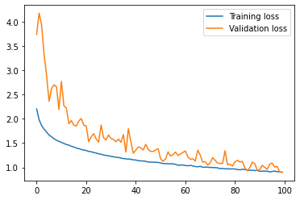

```python
# Plot the training and validation curves
plt.plot(range(len(train_losses)), train_losses, label='Training loss')
plt.plot(range(len(train_losses)), val_losses, label='Validation loss')
plt.legend()
```

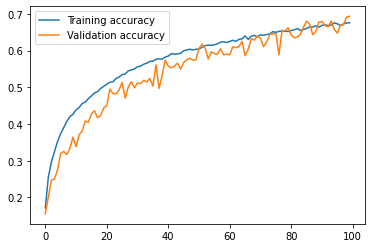

```python
# Plot the training and validation curves
plt.plot(range(len(train_losses)), train_accuracies, label='Training accuracy')
plt.plot(range(len(train_losses)), val_accuracies, label='Validation accuracy')
plt.legend()
```

The network is able to classify the images in the CIFAR10 net with about 70% accuracy.

# Comparison with baseline configurations

In this section, the performance of HyperConvNet is compared to baseline versions (using HyperConvNet definition but training all the layers fully).

```python
loss_hypernet = []
acc_hypernet = []

loss_base = []
acc_base = []
```

```python
# Validation using only one layer of the network

l, acc = validate(model, valloader, criterion, [1, 1, 1, 1, 1])
print(f"loss: {l}, accuracy: {acc}")
loss_hypernet.append(l)
acc_hypernet.append(acc)
```

```
loss: 3.2054453022003173, accuracy: 0.1066
```

```python
# Baseline model and its accuracy for the above activation of the hypernet

model_l1 = HyperConvNet([batch_size, 3, 32, 32], [
    [(16, (3, 2, 1))],
    [(16, (3, 2, 1))],
    [(16, (3, 2, 1))],
    [(16, (3, 2, 1))],
    [(16, (3, 2, 1))]],
    128,
    10)

criterion_l1 = nn.NLLLoss()

optimizer_l1 = optim.SGD(model_l1.parameters(), lr=0.003, momentum=0.9)

epochs = epochs_hypernet

for epoch in range(epochs):
    t_l, t_a = train(model_l1, trainloader, criterion_l1, optimizer_l1, "all")
    v_l, v_a = validate(model_l1, valloader, criterion_l1, "all")
    #print(f"Epoch: {epoch + 1}, training: loss = {t_l}, accuracy = {t_a}, validation: loss = {v_l}, accuracy = {v_a}")

loss_base.append(v_l)
acc_base.append(v_a)

print(f"v_l: {v_l}, v_acc: {v_a}")
```

```
v_l: 0.9344471599578857, v_acc: 0.6664
```

```python
l, acc = validate(model, valloader, criterion, [2, 2, 2, 2, 2])
print(f"loss: {l}, accuracy: {acc}")

loss_hypernet.append(l)
acc_hypernet.append(acc)
```

```
loss: 1.0975501565933228, accuracy: 0.6009
```

```python
# Baseline model and its accuracy for the above activation of the hypernet

model_l2 = HyperConvNet([batch_size, 3, 32, 32], [
    [(16, (3, 2, 1)), (16, (5, 2, 2))],
    [(16, (3, 2, 1)), (16, (5, 2, 2))],
    [(16, (3, 2, 1)), (16, (5, 2, 2))],
    [(16, (3, 2, 1)), (16, (5, 2, 2))],
    [(16, (3, 2, 1)), (16, (5, 2, 2))]],
    128,
    10)

criterion_l2 = nn.NLLLoss()

optimizer_l2 = optim.SGD(model_l2.parameters(), lr=0.003, momentum=0.9)

epochs = epochs_hypernet

for epoch in range(epochs):
    t_l, t_a = train(model_l2, trainloader, criterion_l2, optimizer_l2, "all")
    v_l, v_a = validate(model_l2, valloader, criterion_l2, "all")
    #print(f"Epoch: {epoch + 1}, training: loss = {t_l}, accuracy = {t_a}, validation: loss = {v_l}, accuracy = {v_a}")

loss_base.append(v_l)
acc_base.append(v_a)

print(f"v_l: {v_l}, v_acc: {v_a}")
```

```
v_l: 0.696140069770813, v_acc: 0.7589
```

```python
l, acc = validate(model, valloader, criterion, [3, 3, 3, 3, 3])
print(f"loss: {l}, accuracy: {acc}")

loss_hypernet.append(l)
acc_hypernet.append(acc)
```

```
loss: 0.8380330293655396, accuracy: 0.703
```

```python
# Baseline model and its accuracy for the above activation of the hypernet

model_l3 = HyperConvNet([batch_size, 3, 32, 32], [
    [(16, (3, 2, 1)), (16, (5, 2, 2)), (16, (7, 2, 3))],
    [(16, (3, 2, 1)), (16, (5, 2, 2)), (16, (7, 2, 3))],
    [(16, (3, 2, 1)), (16, (5, 2, 2)), (16, (7, 2, 3))],
    [(16, (3, 2, 1)), (16, (5, 2, 2)), (16, (7, 2, 3))],
    [(16, (3, 2, 1)), (16, (5, 2, 2)), (16, (7, 2, 3))]],
    128,
    10)

criterion_l3 = nn.NLLLoss()

optimizer_l3 = optim.SGD(model_l3.parameters(), lr=0.003, momentum=0.9)

epochs = epochs_hypernet

for epoch in range(epochs):
    t_l, t_a = train(model_l3, trainloader, criterion_l3, optimizer_l3, "all")
    v_l, v_a = validate(model_l3, valloader, criterion_l3, "all")
    #print(f"Epoch: {epoch + 1}, training: loss = {t_l}, accuracy = {t_a}, validation: loss = {v_l}, accuracy = {v_a}")

loss_base.append(v_l)
acc_base.append(v_a)

print(f"v_l: {v_l}, v_acc: {v_a}")
```

```
v_l: 0.6196934617042541, v_acc: 0.7831
```

```python
l, acc = validate(model, valloader, criterion, [4, 4, 4, 4, 4])
print(f"loss: {l}, accuracy: {acc}")

loss_hypernet.append(l)
acc_hypernet.append(acc)
```

```
loss: 0.8165603719711304, accuracy: 0.7133
```

```python
# Baseline model and its accuracy for the above activation of the hypernet

model_l4 = HyperConvNet([batch_size, 3, 32, 32], [
    [(16, (3, 2, 1)), (16, (5, 2, 2)), (16, (7, 2, 3)), (16, (3, 2, 1))],
    [(16, (3, 2, 1)), (16, (5, 2, 2)), (16, (7, 2, 3)), (16, (3, 2, 1))],
    [(16, (3, 2, 1)), (16, (5, 2, 2)), (16, (7, 2, 3)), (16, (3, 2, 1))],
    [(16, (3, 2, 1)), (16, (5, 2, 2)), (16, (7, 2, 3)), (16, (3, 2, 1))],
    [(16, (3, 2, 1)), (16, (5, 2, 2)), (16, (7, 2, 3)), (16, (3, 2, 1))]],
    128,
    10)

criterion_l4 = nn.NLLLoss()

optimizer_l4 = optim.SGD(model_l4.parameters(), lr=0.003, momentum=0.9)

epochs = epochs_hypernet

for epoch in range(epochs):
    t_l, t_a = train(model_l4, trainloader, criterion_l4, optimizer_l4, "all")
    v_l, v_a = validate(model_l4, valloader, criterion_l4, "all")
    #print(f"Epoch: {epoch + 1}, training: loss = {t_l}, accuracy = {t_a}, validation: loss = {v_l}, accuracy = {v_a}")

loss_base.append(v_l)
acc_base.append(v_a)

print(f"v_l: {v_l}, v_acc: {v_a}")
```

```
v_l: 0.629813018989563, v_acc: 0.781
```

```python
l, acc = validate(model, valloader, criterion, [5, 5, 5, 5, 5])
print(f"loss: {l}, accuracy: {acc}")

loss_hypernet.append(l)
acc_hypernet.append(acc)
```

```
loss: 0.8289929364204407, accuracy: 0.7111
```

```python
# Baseline model and its accuracy for the above activation of the hypernet

model_l5 = HyperConvNet([batch_size, 3, 32, 32], [
    [(16, (3, 2, 1)), (16, (5, 2, 2)), (16, (7, 2, 3)), (16, (3, 2, 1)), (16, (5, 2, 2))],
    [(16, (3, 2, 1)), (16, (5, 2, 2)), (16, (7, 2, 3)), (16, (3, 2, 1)), (16, (5, 2, 2))],
    [(16, (3, 2, 1)), (16, (5, 2, 2)), (16, (7, 2, 3)), (16, (3, 2, 1)), (16, (5, 2, 2))],
    [(16, (3, 2, 1)), (16, (5, 2, 2)), (16, (7, 2, 3)), (16, (3, 2, 1)), (16, (5, 2, 2))],
    [(16, (3, 2, 1)), (16, (5, 2, 2)), (16, (7, 2, 3)), (16, (3, 2, 1)), (16, (5, 2, 2))]],
    128,
    10)

criterion_l5 = nn.NLLLoss()

optimizer_l5 = optim.SGD(model_l5.parameters(), lr=0.003, momentum=0.9)

epochs = epochs_hypernet

for epoch in range(epochs):
    t_l, t_a = train(model_l5, trainloader, criterion_l5, optimizer_l5, "all")
    v_l, v_a = validate(model_l5, valloader, criterion_l5, "all")
    #print(f"Epoch: {epoch + 1}, training: loss = {t_l}, accuracy = {t_a}, validation: loss = {v_l}, accuracy = {v_a}")

loss_base.append(v_l)
acc_base.append(v_a)

print(f"v_l: {v_l}, v_acc: {v_a}")
```

```
v_l: 0.6009324896812439, v_acc: 0.7933
```

```python
l, acc = validate(model, valloader, criterion, ["all", "all", "all", "all", "all"])
print(f"loss: {l}, accuracy: {acc}")

loss_hypernet.append(l)
acc_hypernet.append(acc)
```

```
loss: 0.8937257551193237, accuracy: 0.6937
```

```python
# Baseline model and its accuracy for the above activation of the hypernet

model_l6 = HyperConvNet([batch_size, 3, 32, 32], [
    [(16, (3, 2, 1)), (16, (5, 2, 2)), (16, (7, 2, 3)), (16, (3, 2, 1)), (16, (5, 2, 2)), (16, (7, 2, 3))],
    [(16, (3, 2, 1)), (16, (5, 2, 2)), (16, (7, 2, 3)), (16, (3, 2, 1)), (16, (5, 2, 2)), (16, (7, 2, 3))],
    [(16, (3, 2, 1)), (16, (5, 2, 2)), (16, (7, 2, 3)), (16, (3, 2, 1)), (16, (5, 2, 2)), (16, (7, 2, 3))],
    [(16, (3, 2, 1)), (16, (5, 2, 2)), (16, (7, 2, 3)), (16, (3, 2, 1)), (16, (5, 2, 2)), (16, (7, 2, 3))],
    [(16, (3, 2, 1)), (16, (5, 2, 2)), (16, (7, 2, 3)), (16, (3, 2, 1)), (16, (5, 2, 2)), (16, (7, 2, 3))]],
    128,
    10)

criterion_l6 = nn.NLLLoss()

optimizer_l6 = optim.SGD(model_l6.parameters(), lr=0.003, momentum=0.9)

epochs = epochs_hypernet

for epoch in range(epochs):
    t_l, t_a = train(model_l6, trainloader, criterion_l6, optimizer_l6, "all")
    v_l, v_a = validate(model_l6, valloader, criterion_l6, "all")
    #print(f"Epoch: {epoch + 1}, training: loss = {t_l}, accuracy = {t_a}, validation: loss = {v_l}, accuracy = {v_a}")

loss_base.append(v_l)
acc_base.append(v_a)

print(f"v_l: {v_l}, v_acc: {v_a}")
```

```
v_l: 0.6077075807094574, v_acc: 0.7967
```

| HyperConvNetLayer Configurations | Classification Accuracy (%) | Baseline Accuracy (%) | Time to train baseline (min) |
| --- | --- | --- | --- |
| (16, (3, 2, 1)) | 10 | 66 | 18 |
| (16, (3, 2, 1)), (16, (5, 2, 2)) | 60 | 75 | 37 |
| (16, (3, 2, 1)), (16, (5, 2, 2)), (16, (7, 2, 3)) | 70 | 78 | 85 |
| (16, (3, 2, 1)), (16, (5, 2, 2)), (16, (7, 2, 3)), (16, (3, 2, 1)) | 71 | 78 | 117 |
| (16, (3, 2, 1)), (16, (5, 2, 2)), (16, (7, 2, 3)), (16, (3, 2, 1)), (16, (5, 2, 2)) | 71 | 79 | 185 |
| (16, (3, 2, 1)), (16, (5, 2, 2)), (16, (7, 2, 3)), (16, (3, 2, 1)), (16, (5, 2, 2)), (16, (7, 2, 3)) | 69 | 79 | 281 |

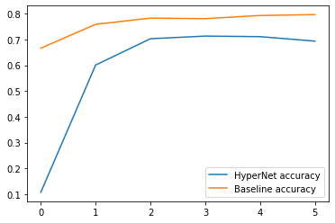

```python
plt.plot(range(len(acc_hypernet)), acc_hypernet, label='HyperNet accuracy')
plt.plot(range(len(acc_base)), acc_base, label='Baseline accuracy')
plt.legend()
```

# Conclusion

# Next steps

I am so excited to share this work with the ML community. There are some interesting possible continuations of this work. For those, who are learning and want to get deeper in the code, these could serve as nice learning problems.

- Transfer learning - Use the lower layers trained from one HyperConvNet for a different image dataset
- Stochastic determination of more potent boundaries (biased towards uisng lessers components) during trainin
- Applying this concept in the presence of feed-forward layers in architectures such as ResNet and UNet.
- Train different layers for different fidelities of input and then combine them in modular way